[figure not shown]

# **Análisis financiero acerca del mercado retail en supermercados de Estados Unidos desde el 2014 hasta el 2017**

# Introducción

Para comprobar la importancia, la trascendencia y la viabilidad del estudio presentado, en esta parte se habla del motivo del estudio y de la metodología que se empleará. Luego, se presenta una preparación de lo que se ha trabajado hasta la fecha de hoy. Además, se tratará una previsión acertada y concreta de lo que se hará a partir de ahora.

## Relevancia:

En la actualidad, las estrategias de marketing han ido evolucionando y progresando conforme la complejidad para analizar al comprador potencial ha ido creciendo. Por ello, vemos relevante e importante la propuesta que presentamos puesto que permitirá, por ejemplo, crear modelos de regresión para predecir futuras ventas y ganancias de algunos supermercados. Dado que algunos de nosotros llevamos el curso de empresa y consumidor, somos capaces de comprender y analizar correctamente la base de datos anteriormente presentada. La utilidad que le encontramos a este es descubrir qué productos y categorías funcionan mejor en qué regiones, segmentos de clientes, etc. El tema propuesto es bastante completo gracias a la cantidad de información que podemos sustraer de la fuente obtenida, y su importancia en el sector especificado. Nos va a permitir obtener distintas conclusiones y gráficos los cuales pueden tener mucho valor con respecto a la demanda y competencia del negocio.

# Objetivos:

## Objetivo principal:

Identificar los factores relacionados con mayores ventas y ganancias de un superstore para saber a qué productos, regiones, categorías y segmentos de clientes deberían orientarse.

## Objetivo secundario:

- Establecer relaciones entre las variables que permitan observar que productos y categorías generan mayores ventas y ganancias en las regiones, segmentos, etc.
- Obtener el promedio de descuentos y beneficio por región.

## Datos:

## Recolección de datos:

> La base de datos que escogimos la encontramos en Kaggle (Web especializada en Data Science donde podemos encontrar muchisimas bases de datos, escogimos usar esta web porque es bastante conocida y las bases de datos encontradas en este sitio son muy buenas. Ademas, unos dias despues en clase nos recomendaron buscar ahi nuestras bases de datos.) Esta base de datos originalmente proviene de Tableau, (compania sobre visualizacion de data que se centra en intelligencia de mercado). Estabamos buscando una base de datos con minimo 6 variables categoricas y numericas la cual podamos entender sin mayor complicacion y creamos que se pueda hacer un analisis bastante interesante. La muestra de poblacion que usamos es unicamente de Estados Unidos (Estados y Ciudades) entre 2014 y 2017.

## Población, muestra y muestreo

### 1) Poblacion Objetivo

> Los sujetos estudiados son los clientes que compran en supermercados, establecimientos especializados, tiendas, y todo lo que constituye el mercado retail.

### 2) Unidad Muestral

> La muestra del estudio es el mercado retail, ya que se registran los patrones de comportamientos, gustos, características, etc. de los clientes que van consumiendo productos de este mercado al pasar un cierto tiempo.

> De aquí podemos destacar que la unidad muestral del estudio es definida como una de las tiendas en las que se estudia dicho segmento de población.

### 3) Tipo de Muestreo

> El tipo de muestra es probabilístico, muestreo de conglomerados ya que se agrupa un segmento de la población de diferentes ciudades y en grandes cantidades, además de que con eso podría estudiarse aleatoriamente a cualquier cliente en cualquier ciudad, esto concuerda con la definición del tipo de muestreo mencionado anteriormente, conjunto de elementos poblacionales que se podrían dividir por segmentos como localidad, pero se eligen de forma aleatoria.

## Variables

### Numéricas

#### Numéricas discretas

| Variables | Restriccion |
| --- | --- |
| Cantidad | Entero positivo |

#### Numéricas continuas

| Variables | Restriccion |
| --- | --- |
| Ventas |  |
| Descuento | Numero entre 0 y 1 |
| Beneficio |  |

### Categóricas

#### Categóricas nominales

[output not shown]

#### Categórica ordinal

[output not shown]

## Librerias

```r
#lista.paquetes <- c("readr", "dplyr", "reshape2","ggfortify", "ggplot2", "lubridate")
#nuevos.paquetes <- lista.paquetes[!(lista.paquetes %in% installed.packages()[,"Package"])]
#if(length(nuevos.paquetes)) install.packages(nuevos.paquetes)
```

## Carga de datos

```r
df <- read_csv("Sample - Superstore.csv")
```

## Limpieza de datos

La base de datos que estamos utilizando ya ha sido limpiada y la verdad no hay nada que podamos limpiar / cambiar que nos favorezca o ofrezca alguna utilidad.

```
##  [1] "Row ID"        "Order ID"      "Order Date"    "Ship Date"
##  [5] "Ship Mode"     "Customer ID"   "Customer Name" "Segment"
##  [9] "Country"       "City"          "State"         "Postal Code"
## [13] "Region"        "Product ID"    "Category"      "Sub-Category"
## [17] "Product Name"  "Sales"         "Quantity"      "Discount"
## [21] "Profit"
```

```
##      Row ID       Order ID          Order Date         Ship Date
##  Min.   :   1   Length:9994        Length:9994        Length:9994
##  1st Qu.:2499   Class :character   Class :character   Class :character
##  Median :4998   Mode  :character   Mode  :character   Mode  :character
##  Mean   :4998
##  3rd Qu.:7496
##  Max.   :9994
##   Ship Mode         Customer ID        Customer Name        Segment
##  Length:9994        Length:9994        Length:9994        Length:9994
##  Class :character   Class :character   Class :character   Class :character
##  Mode  :character   Mode  :character   Mode  :character   Mode  :character
##
##
##
##    Country              City              State           Postal Code
##  Length:9994        Length:9994        Length:9994        Length:9994
##  Class :character   Class :character   Class :character   Class :character
##  Mode  :character   Mode  :character   Mode  :character   Mode  :character
##
##
##
##     Region           Product ID          Category         Sub-Category
##  Length:9994        Length:9994        Length:9994        Length:9994
##  Class :character   Class :character   Class :character   Class :character
##  Mode  :character   Mode  :character   Mode  :character   Mode  :character
##
##
##
##  Product Name           Sales              Quantity        Discount
##  Length:9994        Min.   :    0.444   Min.   : 1.00   Min.   :0.0000
##  Class :character   1st Qu.:   17.280   1st Qu.: 2.00   1st Qu.:0.0000
##  Mode  :character   Median :   54.490   Median : 3.00   Median :0.2000
##                     Mean   :  229.858   Mean   : 3.79   Mean   :0.1562
##                     3rd Qu.:  209.940   3rd Qu.: 5.00   3rd Qu.:0.2000
##                     Max.   :22638.480   Max.   :14.00   Max.   :0.8000
##      Profit
##  Min.   :-6599.978
##  1st Qu.:    1.729
##  Median :    8.666
##  Mean   :   28.657
##  3rd Qu.:   29.364
##  Max.   : 8399.976
```

```r
df$Country <- NULL
df$`Postal Code` <- NULL
df$`Order ID` <- NULL
df$`Customer Name` <- NULL
```

## **Análisis descriptivo**

```r
summary(df)
```

```
##      Row ID      Order Date         Ship Date          Ship Mode
##  Min.   :   1   Length:9994        Length:9994        Length:9994
##  1st Qu.:2499   Class :character   Class :character   Class :character
##  Median :4998   Mode  :character   Mode  :character   Mode  :character
##  Mean   :4998
##  3rd Qu.:7496
##  Max.   :9994
##  Customer ID          Segment              City              State
##  Length:9994        Length:9994        Length:9994        Length:9994
##  Class :character   Class :character   Class :character   Class :character
##  Mode  :character   Mode  :character   Mode  :character   Mode  :character
##
##
##
##     Region           Product ID          Category         Sub-Category
##  Length:9994        Length:9994        Length:9994        Length:9994
##  Class :character   Class :character   Class :character   Class :character
##  Mode  :character   Mode  :character   Mode  :character   Mode  :character
##
##
##
##  Product Name           Sales              Quantity        Discount
##  Length:9994        Min.   :    0.444   Min.   : 1.00   Min.   :0.0000
##  Class :character   1st Qu.:   17.280   1st Qu.: 2.00   1st Qu.:0.0000
##  Mode  :character   Median :   54.490   Median : 3.00   Median :0.2000
##                     Mean   :  229.858   Mean   : 3.79   Mean   :0.1562
##                     3rd Qu.:  209.940   3rd Qu.: 5.00   3rd Qu.:0.2000
##                     Max.   :22638.480   Max.   :14.00   Max.   :0.8000
##      Profit
##  Min.   :-6599.978
##  1st Qu.:    1.729
##  Median :    8.666
##  Mean   :   28.657
##  3rd Qu.:   29.364
##  Max.   : 8399.976
```

## Envios

Tiempo de Envio vs El tipo de envio Como podemos observar, en tiempos: Mismo dia < Primera Clase < Second Class < Standard Class

```r
df<-df%>%
  mutate(`Order Date` = mdy(`Order Date`),
         `Ship Date` = mdy(`Ship Date`),
         ship = `Ship Date` - `Order Date`)
```

[output not shown]

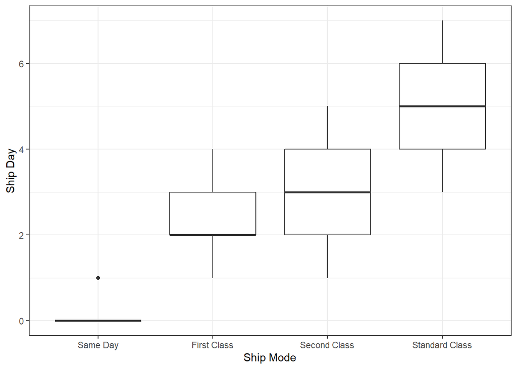

```r
df%>%
  ggplot(aes(reorder(`Ship Mode`,ship,median), ship))+
  geom_boxplot()+
  labs(x='Ship Mode',
       y='Ship Day')+
  theme_bw()
```

## Sub-Categoria

Porcentaje de tipos de envio por cada sub-categoria de producto, como podemos ver no hay ninguno que destaque alguna observacion o algo entre ellos

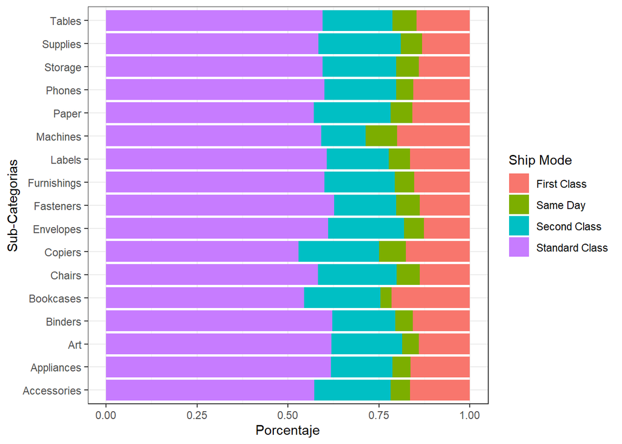

## Segmento de Cliente

Porcentage de tipos de envio por tipo de cliente. De nuevo, no hay ninguna observacion destacable.

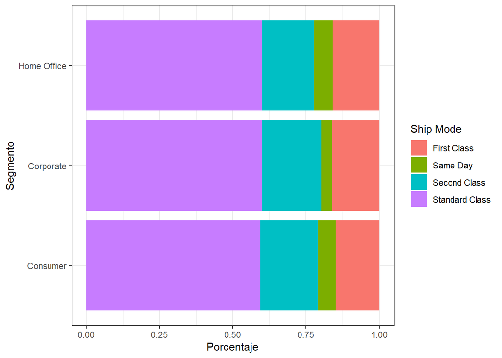

Ventas con respecto a las sub categorias y tipo de cliente en un mapa de calor.

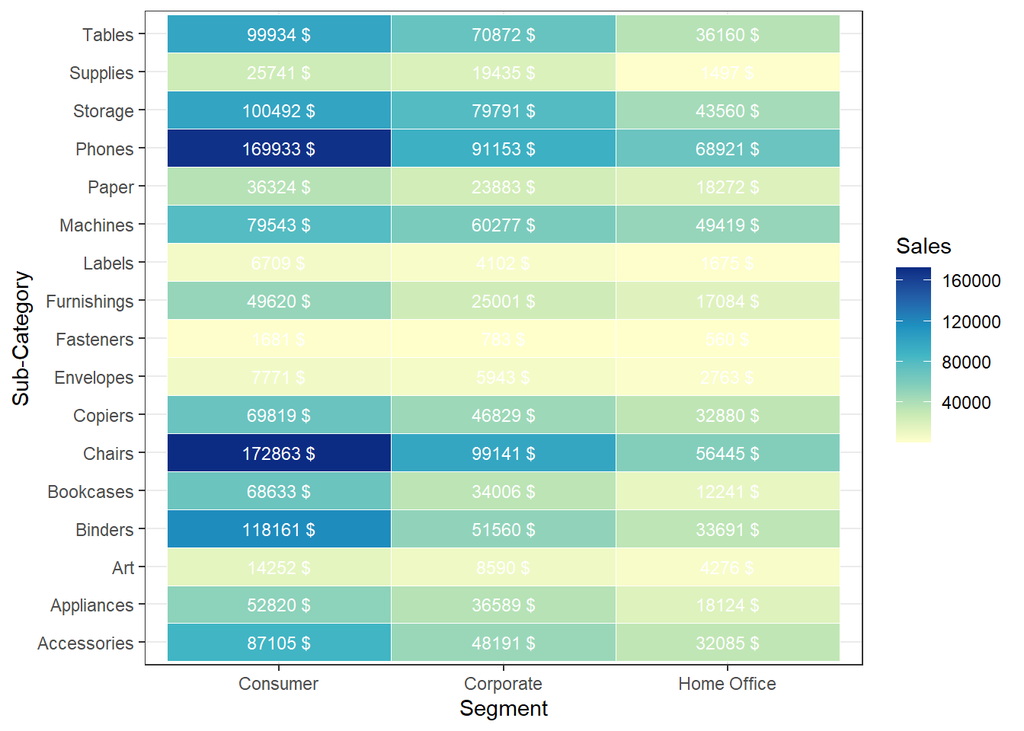

## Estado

Porcentaje de tipos de cliente por estado y Porcentaje de tipos de envio por estado. Aca si podemos observar que hay una diferencia entre estados, en la de segmentacion sobretodo ya que en la de envios es cierto que hay algunos estados que se salen del tipico patron que hemos estado observando.

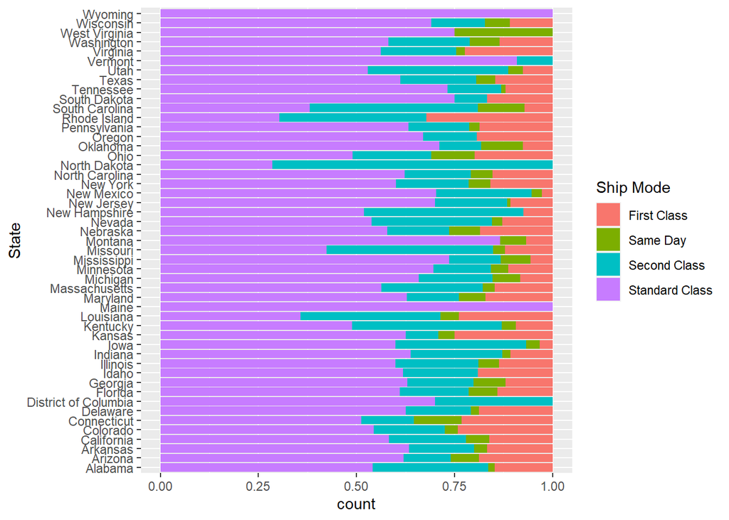

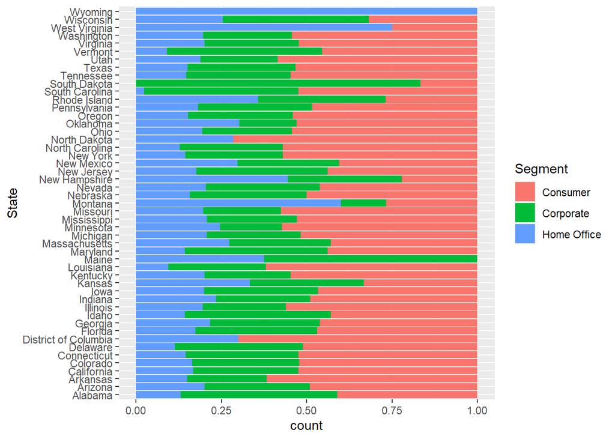

## Region

Con ayuda del barplot podemos observar las Regiones que se encuentran por encima del promedio de la ganancia. Asimismo tambien podemos observar las Regiones que tienen mayores descuentos por productos. Con esta información podríamos realizar algunas hipótesis más adelante.

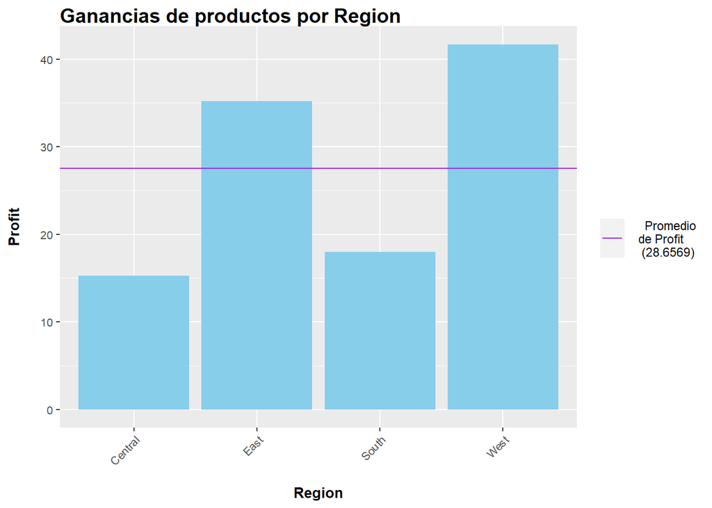

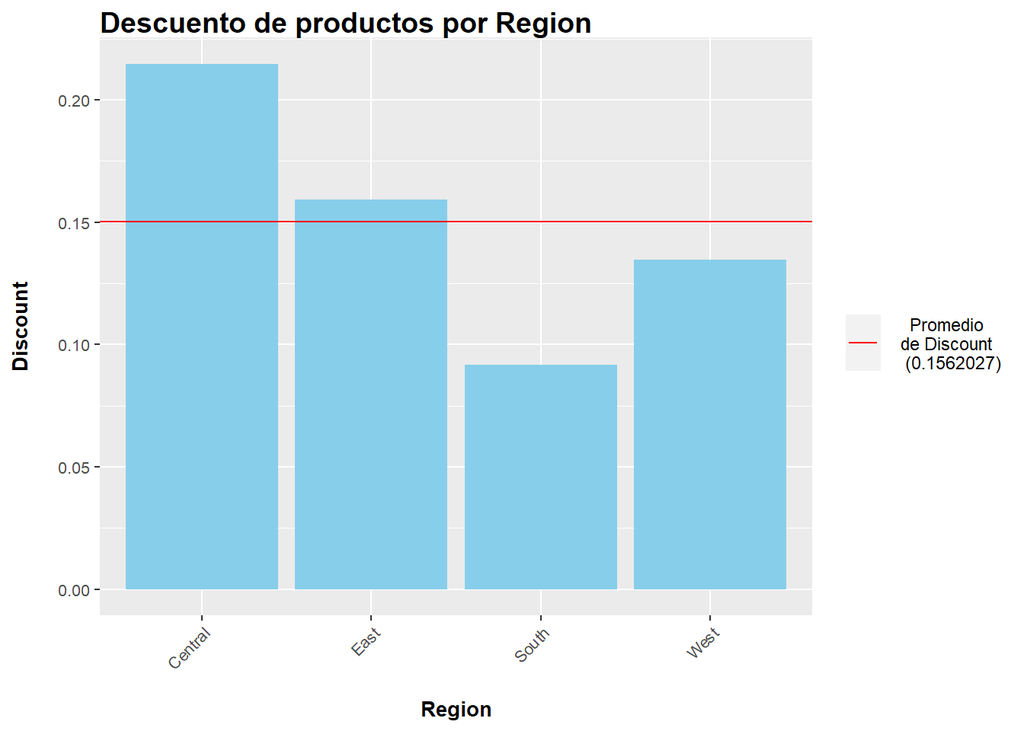

## Ventas

Analisis de la variable Sales

```
##      Min.   1st Qu.    Median      Mean   3rd Qu.      Max.
##     0.444    17.280    54.490   229.858   209.940 22638.480
```

Sobre esta variable recordemos el promedio(Mean), ya que podra ser usada para poder determinar o resolver distintos problemas entorno al contexto de las ventas de los mercados retail.

```
## [1] 229.858
```

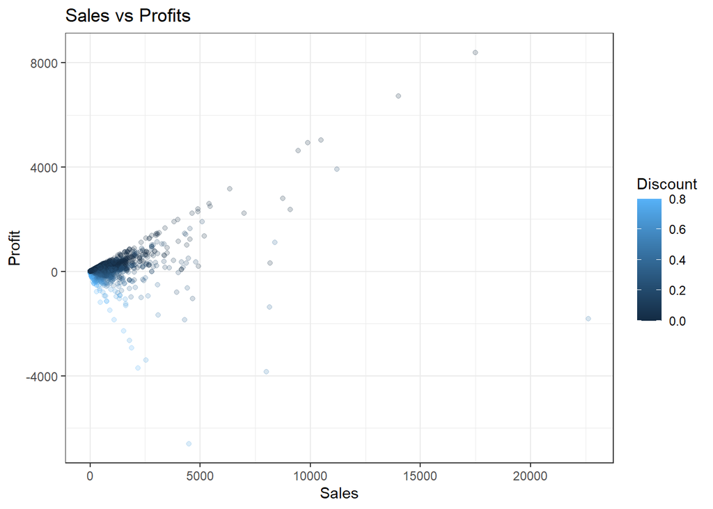

```r
df%>%
  ggplot(aes(Sales, Profit, color=Discount))+
  geom_point(alpha=1/5)+
  theme_bw()+
  labs(title = 'Sales vs Profits')
```

## Descuento

El resumen acerca de la variable Discount se ve reflejada en este recuadro, en donde muestra las siguientes medidas para la descripción de la variable (Mínimo, 1er cuartil, Mediana, Promedio, 3er cuartil, Máximo):

```
##    Min. 1st Qu.  Median    Mean 3rd Qu.    Max.
##  0.0000  0.0000  0.2000  0.1562  0.2000  0.8000
```

Sobre esta variable recordemos el promedio(Mean), ya que podra ser usada para poder determinar o resolver distintos problemas entorno al contexto del cuanto es el descuento promedio de los mercados retail.

```
## [1] 0.1562027
```

Como afecta el descuento a la ganancia de cada sub categoria en cada categoria.

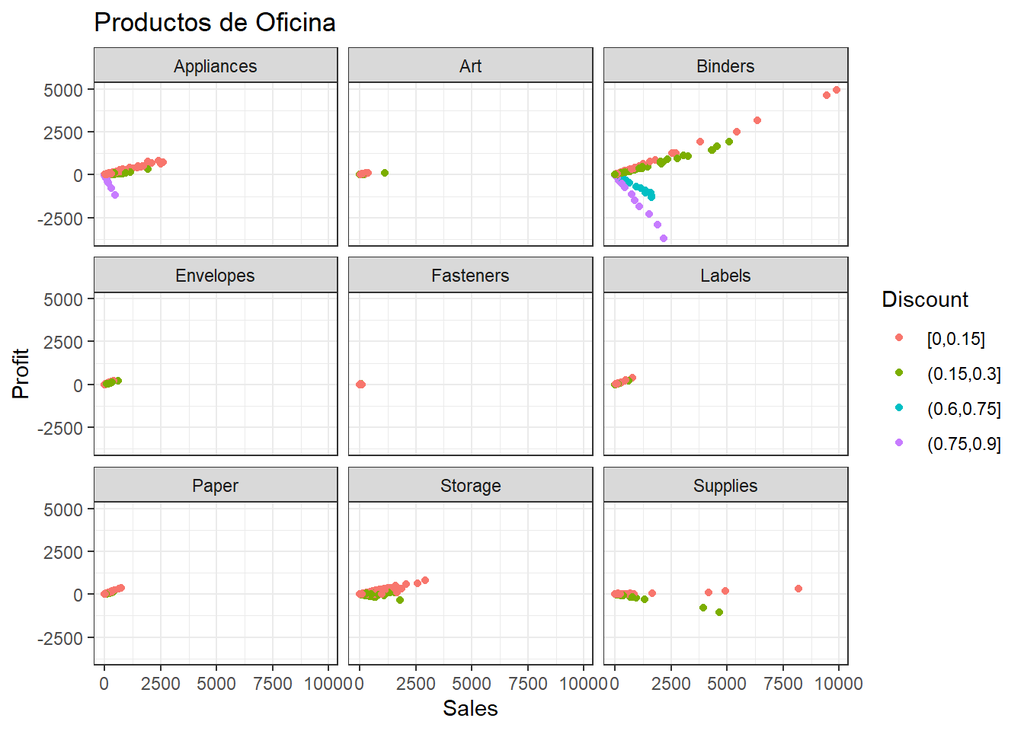

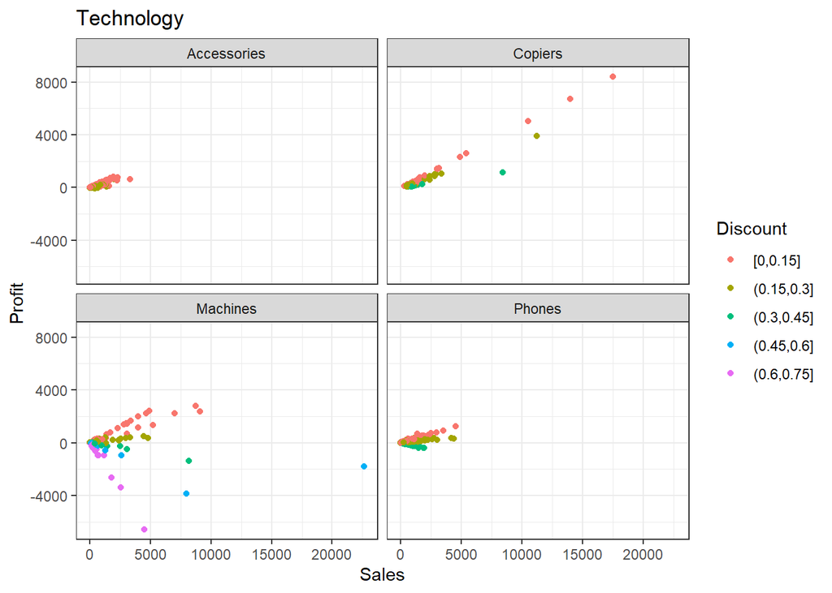

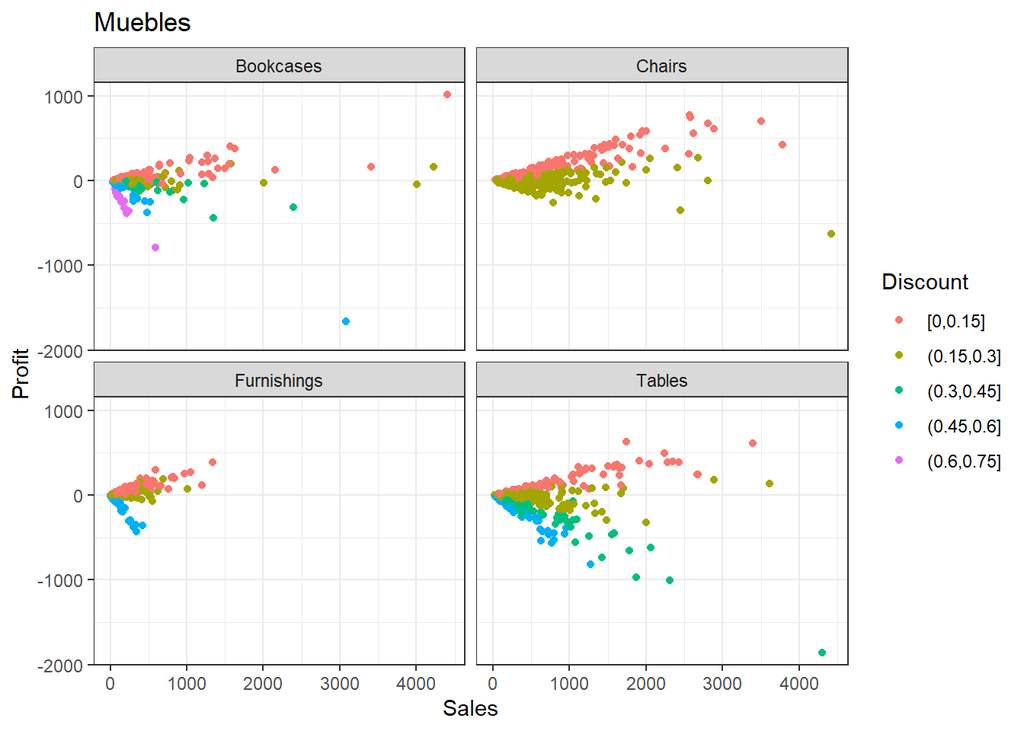

## Profit

El resumen acerca de la variable Profit se ve reflejada en este recuadro, en donde muestra las siguientes medidas para la descripción de la variable (Mínimo, 1er cuartil, Mediana, Promedio, 3er cuartil, Máximo):

```
##      Min.   1st Qu.    Median      Mean   3rd Qu.      Max.
## -6599.978     1.729     8.666    28.657    29.364  8399.976
```

Sobre esta variable recordemos el minimo(MIN) , el maximo(Max) y el promedio (Mean), ya que podra ser usada para poder determinar o resolver distintos problemas entorno al contexto de cuanto es el beneficio minimo , maximo y promedio.

```
## [1] -6599.978
```

```
## [1] 28.6569
```

```
## [1] 8399.976
```

```
##    Min. 1st Qu.  Median    Mean 3rd Qu.    Max.
##    1.00    2.00    3.00    3.79    5.00   14.00
```

Sobre esta variable recordemos el promedio(Mean), ya que podra ser usada para poder determinar o resolver distintos problemas entorno a la cantidad del producto

```
## [1] 3.789574
```

```
##
##       Furniture Office Supplies      Technology
##            2121            6026            1847
```